# 平滑方法

## 什麼是平滑方法？為什麼要做平滑方法？

- 透過演算法來移除資料中的隨機性，凸顯資料的趨勢(視覺化)
- 技術分析
- 本投影片主要介紹平滑曲線的相關方法

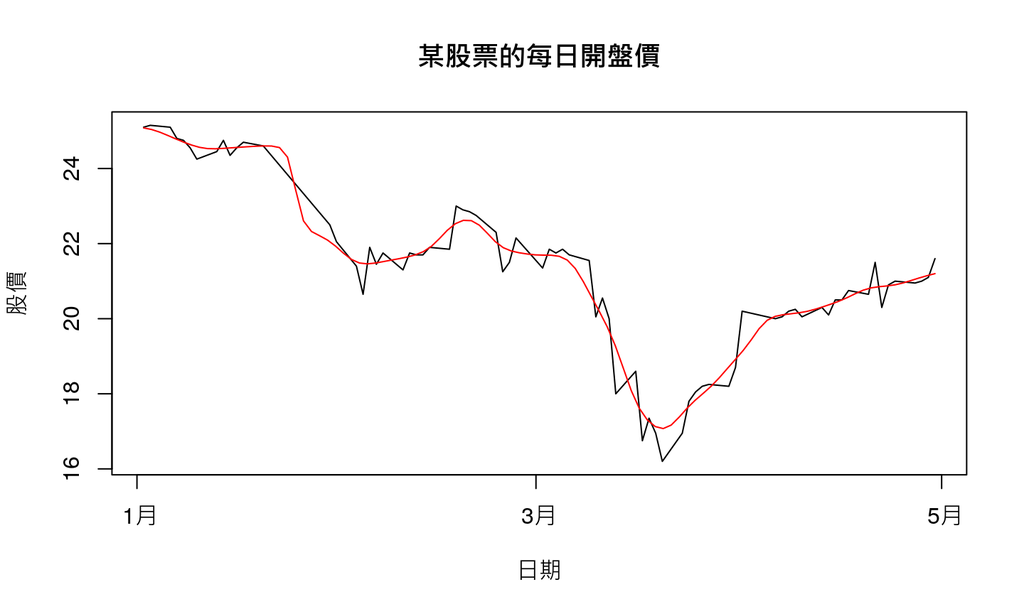

## 常見的平滑方法

- 給定\(S = \{(x_1, y_1), (x_2, y_2), ..., (x_n, y_n)\}\)，要找到\(f\)使得\(f(x)\)是一條平滑的曲線

### 範例：移動平均法。計算\(x\)周圍的資料點的平均

- \(N(x,d) = \{x_i|x_i \in S, \left| x_i - x \right| < d\}\) 代表接近x的資料點，（距離小於\(d\)）
- \(\left\lVert N(x,d) \right\rVert\) 代表x 周圍的點的數量

\[f(x) = \frac{1}{\left\lVert N(x,d) \right\rVert} \sum_{x_i \in N(x, d)} y_i\]

## 常見的平滑方法的原理

1. Kernel
2. Spline

## Kernel方法

- \(f(x)\)的值由\(x\)周圍的點所確定

### 範例

- 移動平均
- 加權移動平均
  - 不同的「權重」算法（不同的kernel）

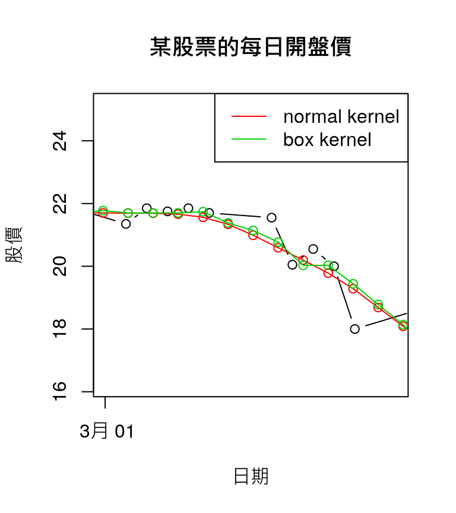

## Kernel 方法

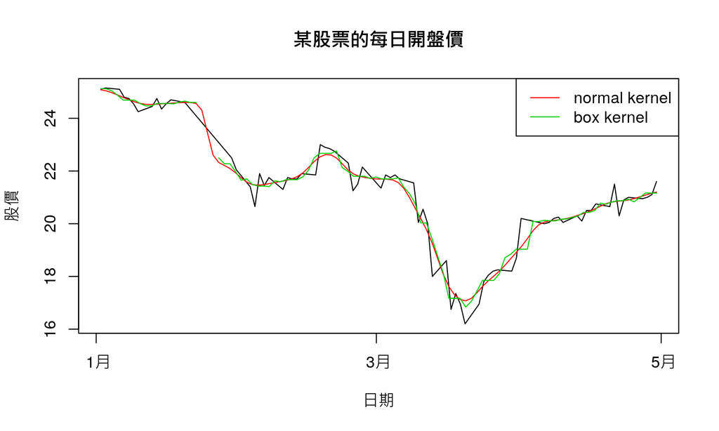

## Spline方法

- 將 \(f\) 視為一些**基礎函數**的**線性組合**
  - 基礎函數可以是從某些觀點出發的，例如從多項式、或是從週期性函數
  - 可以想像成把\(y\)對這些基礎函數搭配\(x\)產生的\(b_1(x), b_2(x), ...\)做迴歸分析

### 範例

- B-spline basis
- Fourier basis

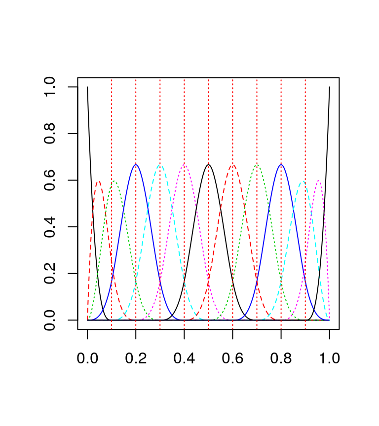

## Spline方法

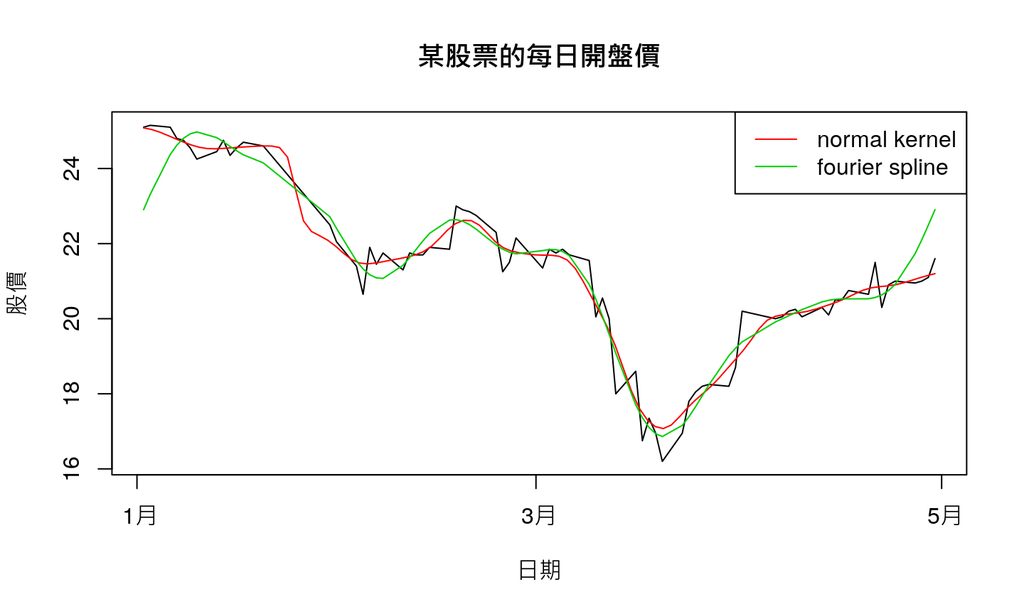

## 個人比較

- 有統計理論證明，兩者（kernel v.s. spline）可以轉換
- kernel方法只需要局部資訊，通常在實作上比較簡單
- spline方法在有特別的應用場景
  - 例如有強烈週期性的資料可以用Fourier basis
  - 外插預測時（例如拿1~4月的資料預測5月）